# Project: Investigate a Dataset (Replace this with something more specific!)

### Research Question 2 (Average revenue of each movie year to year )

```python
#Avg_revenue= df1['revenue'].mean()
#print("average revenue of each movie in the data set is "+format(Avg_revenue))

df_revenue = df1.groupby('release_year')['revenue'].mean()

df_revenue
```

```
release_year
1960    2.580100e+07
1961    3.377202e+07
1962    2.947569e+07
1963    2.942115e+07
1964    4.694479e+07
1965    9.161637e+07
1966    1.694734e+07
1967    5.629497e+07
1968    2.469131e+07
1969    5.742677e+07
1970    4.999745e+07
1971    2.894513e+07
1972    6.011252e+07
1973    9.291776e+07
```

[output cut: 43 more lines]

```
Text(0,0.5,'Revenues in dollars')
```

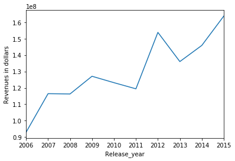

```python
# Analysing only last 10 years
df_revenue = df_revenue.tail(10)
plot_2 = df_revenue.plot()
plot_2.set_xlabel("Release_year")
plot_2.set_ylabel("Revenues in dollars")
```

**Observations** Overall from year to year revenues were increasing . 2015 had highest revenue compared to the previous 10 years from the plot

```python
# analysing profits for the last ten years

df_profit =  pd.concat([df_budget, df_revenue], axis=1)


df_profit
```

| release_year | budget | revenue |
| --- | --- | --- |
| 2006 | 4.106677e+07 | 9.297332e+07 |
| 2007 | 4.334422e+07 | 1.164684e+08 |
| 2008 | 4.364356e+07 | 1.162914e+08 |
| 2009 | 4.427822e+07 | 1.270826e+08 |
| 2010 | 4.777479e+07 | 1.231703e+08 |
| 2011 | 4.303725e+07 | 1.194247e+08 |
| 2012 | 4.831281e+07 | 1.538284e+08 |
| 2013 | 4.783756e+07 | 1.360306e+08 |
| 2014 | 4.481072e+07 | 1.458786e+08 |
| 2015 | 4.481736e+07 | 1.637683e+08 |

```
Text(0,0.5,'Budget and Revenue in dollars')
```

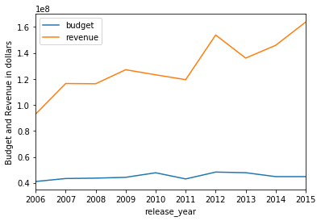

```python
#plotting revenue and budget against years
plot_3 = df_profit.plot()
plot_3.set_xlabel("release_year")
plot_3.set_ylabel("Budget and Revenue in dollars")
```

```
array([[<matplotlib.axes._subplots.AxesSubplot object at 0x7fac7d0b7cf8>,
        <matplotlib.axes._subplots.AxesSubplot object at 0x7fac795fb198>]], dtype=object)
```

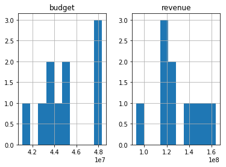

```python
df_profit.hist()
```

### Research Question 3 (Average runtime of each movie )

```python
#calculating average runtime overall

Avg_runtime = df1['runtime'].mean()
print("average runtime of each movie in the dataset is "+format(Avg_runtime))
```

```
average runtime of each movie in the dataset is 109.3623949579832
```

### Research Question 4 ( Movies with least and most Popularity)

```python
#min value in popularity column
df.loc[df['popularity'].idxmax()]
```

```
imdb_id                                                         tt0369610
popularity                                                        32.9858
budget                                                          150000000
revenue                                                        1513528810
cast                    Chris Pratt|Bryce Dallas Howard|Irrfan Khan|Vi...
director                                                  Colin Trevorrow
runtime                                                               124
genres                          Action|Adventure|Science Fiction|Thriller
production_companies    Universal Studios|Amblin Entertainment|Legenda...
vote_count                                                           5562
release_year                                                         2015
Name: 0, dtype: object
```

```python
#min value in popularity column
df.loc[df['popularity'].idxmin()]
```

```
imdb_id                                                         tt1966566
popularity                                                       0.010335
budget                                                           30000000
revenue                                                          68129518
cast                    Thomas Kretschmann|Yanina Studilina|Philippe R...
director                                                Fyodor Bondarchuk
runtime                                                               131
genres                                                         War|Action
production_companies                                  Art Pictures Studio
vote_count                                                             64
release_year                                                         2013
Name: 6065, dtype: object
```

### Research Question 5( Popular Genres from year to year )

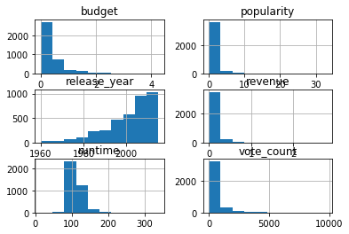

```python
#We might need a histogram to analyse this dataset to find trends

df1.hist();
```

```python
#analysing popular genres
#split generes that are seperated by |
def split(column):
    #will recieve a column that has strings seperated by pipe
    data = df1[column].str.cat(sep='|')

    #giving input as pandas series and storing values individually in different rows
    data = pd.Series(data.split('|'))

    #arranging in descending order
    count = data.value_counts(ascending=False)

    return count

pop_genre = split('genres')
 #printing top 5 values
pop_genre.head()
#check unique values of genres and find top 5 popular genres

#pop_genre =df1['genres'].value_counts()

#pop_genre = df1.groupby('genres')
#pop_genre.head()

pop_genre
```

```
Drama              1731
Comedy             1336
Thriller           1195
Action             1076
Adventure           743
Romance             659
Crime               649
Science Fiction     517
Horror              459
Family              417
Fantasy             395
Mystery             343
Animation           199
Music               132
History             128
War                 119
Western              52
Documentary          28
Foreign              10
TV Movie              1
dtype: int64
```

**Observations** From the above script, we found that Top genres are Drama, Comedy, Thriller, Action , Adventure . These genres had most number of counts but we cannot be assured that they are popular .So further analysis is required.

```python
#group by to filter genres based on release year
genre_df = df1.groupby(['genres','release_year'])

genre_df_mean = genre_df.mean()

genre_df_mean
#genre_df['genres'].value_counts()
```

| genres | release_year | popularity | budget | revenue | runtime | vote_count |
| --- | --- | --- | --- | --- | --- | --- |
| Action | 1988 | 1.392581 | 1.500000e+06 | 1.180612e+07 | 92.000000 | 180.000000 |
|  | 1993 | 0.207999 | 6.000000e+06 | 3.283371e+06 | 99.000000 | 12.000000 |
|  | 2001 | 0.208670 | 9.400000e+07 | 5.474474e+07 | 116.000000 | 90.000000 |
|  | 2002 | 1.936728 | 7.000000e+07 | 2.774484e+08 | 124.000000 | 849.000000 |
|  | 2003 | 0.626183 | 2.175209e+07 | 5.248079e+07 | 100.333333 | 166.333333 |
|  | 2004 | 0.344278 | 4.000000e+07 | 4.654620e+07 | 84.000000 | 69.000000 |
|  | 2005 | 0.927509 | 8.600000e+07 | 9.885314e+07 | 115.333333 | 240.333333 |
|  | 2006 | 0.566476 | 4.700000e+07 | 3.916684e+07 | 142.000000 | 121.500000 |
|  | 2007 | 0.431510 | 4.500000e+07 | 3.082286e+07 | 99.000000 | 92.000000 |
|  | 2008 | 1.172718 | 3.500000e+07 | 8.541690e+07 | 100.000000 | 359.000000 |
|  | 2009 | 0.975593 | 4.900000e+07 | 6.662475e+07 | 119.000000 | 312.000000 |
|  | 2010 | 1.686804 | 1.200000e+08 | 2.233348e+08 | 125.000000 | 698.500000 |
|  | 2012 | 0.767413 | 1.500000e+07 | 1.560854e+07 | 96.000000 | 244.000000 |
|  | 2015 | 4.566713 | 1.500000e+08 | 6.823301e+08 | 131.000000 | 2349.000000 |
| Action\|Adventure | 1972 | 0.321141 | 5.000000e+06 | 8.456312e+07 | 117.000000 | 144.000000 |
|  | 1995 | 0.981049 | 9.800000e+07 | 1.851732e+07 | 119.000000 | 54.000000 |
|  | 1996 | 1.049888 | 3.000000e+07 | 5.740055e+07 | 95.000000 | 63.000000 |
|  | 2014 | 1.283694 | 5.950000e+07 | 1.040598e+08 | 96.000000 | 625.000000 |
| Action\|Adventure\|Animation\|Family\|Fantasy | 2011 | 1.071695 | 1.300000e+08 | 5.549875e+08 | 90.000000 | 48.000000 |
| Action\|Adventure\|Animation\|Family\|Science Fiction | 2004 | 3.339406 | 9.200000e+07 | 6.314421e+08 | 115.000000 | 3064.000000 |
| Action\|Adventure\|Animation\|Science Fiction | 2008 | 0.480116 | 3.500000e+06 | 5.231128e+06 | 75.000000 | 66.000000 |
| Action\|Adventure\|Animation\|Science Fiction\|Thriller | 2009 | 2.846465 | 3.000000e+07 | 4.842806e+07 | 79.000000 | 851.000000 |
| Action\|Adventure\|Comedy | 1965 | 0.622157 | 5.600000e+06 | 2.995000e+07 | 138.000000 | 19.000000 |
|  | 1985 | 0.887605 | 1.250000e+07 | 2.382270e+05 | 100.000000 | 50.000000 |
|  | 1986 | 0.642842 | 2.500000e+07 | 7.981794e+07 | 94.000000 | 152.000000 |
|  | 1989 | 1.362379 | 5.500000e+07 | 6.340861e+07 | 104.000000 | 239.000000 |
|  | 1991 | 0.977243 | 6.500000e+07 | 1.721808e+07 | 100.000000 | 155.000000 |
|  | 1993 | 0.794564 | 3.000000e+07 | 5.389884e+07 | 105.000000 | 112.000000 |
|  | 1999 | 0.585123 | 7.500000e+07 | 1.080000e+08 | 114.000000 | 412.000000 |
|  | 2000 | 1.161107 | 2.600000e+07 | 7.100000e+07 | 106.000000 | 662.000000 |
| ... | ... | ... | ... | ... | ... | ... |
| War\|Adventure\|Drama\|Romance | 1995 | 0.194078 | 3.500000e+07 | 1.500000e+07 | 135.000000 | 17.000000 |
|  | 2002 | 0.534397 | 3.500000e+07 | 2.988264e+07 | 132.000000 | 81.000000 |
| War\|Adventure\|Science Fiction | 2015 | 5.476958 | 1.600000e+08 | 6.505234e+08 | 136.000000 | 2380.000000 |
| War\|Crime\|Drama\|Mystery\|Romance | 2006 | 0.437529 | 3.200000e+07 | 5.914908e+06 | 108.000000 | 46.000000 |
| War\|Drama | 1968 | 0.378658 | 7.000000e+06 | 1.100000e+07 | 142.000000 | 17.000000 |
|  | 2008 | 1.610620 | 1.250000e+07 | 2.041656e+07 | 94.000000 | 746.000000 |
|  | 2011 | 0.539108 | 2.000000e+07 | 1.747900e+04 | 113.000000 | 29.000000 |
|  | 2014 | 0.893121 | 2.250000e+07 | 1.552002e+07 | 112.000000 | 287.000000 |
| War\|Drama\|Action | 2014 | 6.415818 | 6.800000e+07 | 2.118179e+08 | 135.000000 | 2572.000000 |
| War\|Drama\|History | 1984 | 0.603541 | 1.440000e+07 | 3.470029e+07 | 141.000000 | 78.000000 |
|  | 2006 | 1.103135 | 9.000000e+07 | 6.590025e+07 | 132.000000 | 308.000000 |
| War\|Drama\|History\|Action | 2014 | 1.779861 | 7.000000e+07 | 1.549840e+08 | 118.000000 | 1083.000000 |
| War\|Drama\|Romance | 1982 | 0.358107 | 6.000000e+06 | 1.027858e+07 | 115.000000 | 31.000000 |
| War\|History\|Action\|Adventure\|Drama | 2004 | 1.319068 | 1.550000e+08 | 1.672982e+08 | 175.000000 | 519.000000 |
| Western | 1962 | 0.507078 | 3.200000e+06 | 8.000000e+06 | 123.000000 | 134.000000 |
|  | 1968 | 0.621202 | 1.800000e+06 | 6.800000e+06 | 114.000000 | 86.000000 |
|  | 1992 | 0.841580 | 1.400000e+07 | 1.591574e+08 | 131.000000 | 602.000000 |
|  | 2003 | 0.680803 | 2.200000e+07 | 6.829629e+07 | 139.000000 | 125.000000 |
|  | 2007 | 1.150389 | 5.500000e+07 | 7.001622e+07 | 122.000000 | 762.000000 |
| Western\|Action | 1961 | 0.173731 | 6.000000e+06 | 4.300000e+06 | 141.000000 | 17.000000 |
| Western\|Action\|Adventure\|Drama | 1962 | 0.526108 | 1.500000e+07 | 5.000000e+07 | 162.000000 | 37.000000 |
| Western\|Adventure | 2004 | 0.815044 | 1.000000e+08 | 1.081034e+08 | 136.000000 | 177.000000 |
| Western\|Animation\|Adventure\|Comedy\|Family | 2002 | 1.040588 | 8.000000e+07 | 1.225635e+08 | 83.000000 | 402.000000 |
| Western\|Animation\|Family\|Comedy\|Music | 2004 | 0.837906 | 1.100000e+08 | 1.039515e+08 | 76.000000 | 210.000000 |
| Western\|Drama | 2006 | 0.463068 | 1.800000e+07 | 1.196307e+06 | 115.000000 | 65.000000 |
|  | 2014 | 0.870104 | 1.600000e+07 | 2.429989e+06 | 122.000000 | 150.000000 |
| Western\|Drama\|Adventure\|Thriller | 2015 | 9.110700 | 1.350000e+08 | 5.329505e+08 | 156.000000 | 3929.000000 |
| Western\|History | 1980 | 0.128234 | 1.000000e+07 | 1.579519e+07 | 99.000000 | 17.000000 |
| Western\|History\|War | 2004 | 0.948560 | 1.450000e+08 | 2.581996e+07 | 137.000000 | 60.000000 |
| Western\|Thriller | 2013 | 0.387592 | 7.000000e+06 | 6.147000e+03 | 95.000000 | 41.000000 |

2701 rows × 5 columns

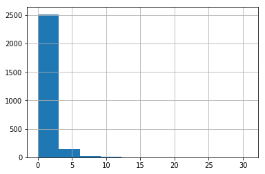

```python
genre_pop_hist = genre_df_mean['popularity'].hist();
```

```python
#describing the stats
genre_df_mean['popularity'].describe()
```

```
count    2701.000000
mean        1.267551
std         1.496105
min         0.010335
25%         0.524096
50%         0.866110
75%         1.459325
max        30.702849
Name: popularity, dtype: float64
```

```python
#
genre_df_mean['popularity'].nlargest(5)
```

```
genres                                     release_year
Action|Adventure|Science Fiction|Thriller  2015            30.702849
Adventure|Drama|Science Fiction            2014            24.949134
Action|Science Fiction|Adventure           2014            14.311205
Adventure|Science Fiction|Thriller         2015            13.112507
Action|Adventure|Science Fiction           2014            12.971027
Name: popularity, dtype: float64
```

**Observations** This shows most popular genres are Action|Adventure|Science Fiction|Thriller based on the popularity ratings of movies under the respective genres

### Research Question 6 ( Popular Production Companies)

```python
#check unique values of production_companies and find top 5 popular individually produced movie productions

#here we can make use of split function to view individual production_companies count

pop_productions = split('production_companies')

pop_productions

#pop_prod =df1['production_companies'].value_counts()
#pop_prod
```

```
Universal Pictures                        329
Warner Bros.                              324
Paramount Pictures                        270
Twentieth Century Fox Film Corporation    201
Columbia Pictures                         178
New Line Cinema                           152
Walt Disney Pictures                      117
Touchstone Pictures                       116
Metro-Goldwyn-Mayer (MGM)                 109
Relativity Media                          102
Columbia Pictures Corporation             101
Miramax Films                              83
TriStar Pictures                           75
Village Roadshow Pictures                  74
DreamWorks SKG                             73
Regency Enterprises                        69
Dimension Films                            51
Summit Entertainment                       50
Amblin Entertainment                       50
Dune Entertainment                         49
Fox 2000 Pictures                          44
Lionsgate                                  44
United Artists                             44
Canal+                                     43
Fox Searchlight Pictures                   41
Silver Pictures                            39
Working Title Films                        39
20th Century Fox                           38
Imagine Entertainment                      38
Legendary Pictures                         37
                                         ...
Sierra/Affinity                             1
D8                                          1
Mythic International Entertainment          1
New Holland Pictures                        1
AMLF                                        1
Swanford Films                              1
Oz Productions Ltd.                         1
Monarchy Enterprises S.a.r.l.               1
Jay Weston Productions                      1
Visiona Romantica                           1
Stone Productions                           1
Exception Wild Bunch                        1
Highway Films                               1
CP Medien AG                                1
Taormina Productions                        1
Havoc                                       1
Permut Presentations                        1
Libra Films                                 1
Say Ahh Productions                         1
Callahan Filmworks                          1
Film Direction                              1
Geneon Entertainment                        1
Curzon Film Distributors                    1
St. Tropez Films                            1
Cannon Productions                          1
Earth Canada Productions                    1
Mutant Enemy Productions                    1
C.O. Films                                  1
Volten                                      1
Exponential Films                           1
Length: 3265, dtype: int64
```

**observation** From the above script we discovered that Universal Pictures,Warner Bros, Paramount pictures etc are top in the list of counts.

This states that these production companies have produced maximum number of movies . This doesnt necessarily signify the fact that these movies are popular .

Hence further analysis is required to be performed

```python
#use groupby to analyse the popularity

prod_df = df1.groupby('production_companies')['popularity'].mean() #selecting most popular movie of each production company
prod_df

#prod_df_mean = prod_df['popularity'].mean()
#prod_df_mean.max()
```

```
production_companies
10th Hole Productions|Benaroya Pictures|Four of a Kind Productions                                                           0.385851
120dB Films|Scion Films|Voodoo Production Services|Chydzik Media Group|First Wedding Productions                             0.520430
1492 Pictures|Dune Entertainment|Fox 2000 Pictures|Sunswept Entertainment|Dune Entertainment III                             2.032753
1492 Pictures|Warner Bros.|Heyday Films                                                                                      8.021423
1492 Pictures|Warner Bros.|Heyday Films|MIRACLE Productions GmbH & Co. KG                                                    6.012584
1492 Pictures|Warner Bros.|Heyday Films|P of A Productions Limited                                                           5.827781
1818|Lone Wolf McQuade Associates|Topkick Productions                                                                        0.290596
20th Century Fox                                                                                                             0.692946
20th Century Fox|1492 Pictures                                                                                               0.263042
20th Century Fox|Chernin Entertainment|Walden Media                                                                          0.494391
20th Century Fox|Davis Entertainment                                                                                         1.651962
20th Century Fox|Double Feature Films|Appian Way|Stone Village Pictures|New Regency Pictures                                 1.321896
20th Century Fox|Figment Films                                                                                               0.626782
20th Century Fox|Gladden Entertainment                                                                                       0.200760
20th Century Fox|Largo Entertainment|JVC Entertainment Networks                                                              0.367997
20th Century Fox|Regency Enterprises                                                                                         0.832959
20th Century Fox|Regency Enterprises|Guy Walks into a Bar Productions|Deep River Productions                                 0.498026
20th Century Fox|Regency Enterprises|New Regency Pictures|Taurus Film|Polar Entertainment Corporation                        0.231418
20th Century Fox|Saban Entertainment                                                                                         0.223994
20th Century Fox|Turner Pictures                                                                                             0.776380
20th Century Fox|Village Roadshow Pictures|NPV Entertainment|Regency Enterprises|Kopelson Entertainment                      0.651040
20th Century Fox|Weed Road Pictures|Dutch Oven|New Regency Productions|Summit Entertainment                                  1.330824
20th Century Fox|Zucker Brothers Productions                                                                                 0.760076
21 Laps Entertainment|Andrew Lauren Productions (ALP)|A24                                                                    1.116296
26 Films                                                                                                                     0.241541
2929 Productions                                                                                                             0.455180
2929 Productions|Dimension Films|Nick Wechsler Productions|Chockstone Pictures                                               1.218657
2929 Productions|Linson Entertainment|Art Linson Productions|Tribeca Productions                                             0.368391
2929 Productions|Magnolia Pictures|Extension 765                                                                             0.272422
3 Arts Entertainment|The Mark Gordon Company                                                                                 0.536350
                                                                                                                               ...
WingNut Films|TriStar Pictures|Key Creatives|Block / Hanson|Canadian Film or Video Production Tax Credit (CPTC)              3.744956
WingNut Films|Universal Pictures                                                                                             0.923851
WingNut Films|Universal Pictures|Big Primate Pictures|MFPV Film                                                              1.508329
Wonderland Sound and Vision|CBS Films|Vast Entertainment                                                                     1.758618
Woods Entertainment|Dimension Films                                                                                          1.286189
Working Dog|Village Roadshow Entertainment                                                                                   0.065672
Working Title Films                                                                                                          2.025604
Working Title Films|Circle Films                                                                                             0.693523
```

[output cut: 8 more lines]

```
Yash Raj Films                                                                                                               0.320908
Zenith Entertainment|Initial Pictures|U.K. Productions Entity                                                                0.506902
Zentropa Entertainments|Danmarks Radio (DR)|Arte|Memfis Film|Isabella Films BV                                               0.449064
Zentropa Entertainments|Det Danske Filminstitut|Danmarks Radio (DR)|Filmstiftung Nordrhein-Westfalen|TrollhÃ¤ttan Film AB    0.953705
Zininsa Film Production|Intellectual Properties Worldwide                                                                    0.168979
Zoetrope Studios                                                                                                             2.319520
Zoetrope Studios|Golan-Globus Productions                                                                                    0.598029
Zweites Deutsches Fernsehen (ZDF)|Les Films Ariane|RAI Radiotelevisione Italiana|Cristaldifilm                               0.889306
abramoff Production|Scorpion Film Production|Abramoff Production                                                             0.076438
area japan                                                                                                                   0.127310
chateau productions                                                                                                          0.439210
erbp                                                                                                                         0.476673
iDeal Partners Film Fund                                                                                                     0.315527
icon                                                                                                                         0.276911
Name: popularity, Length: 3008, dtype: float64
```

```python
#descending order of the above series give the most popular productions
prod_df.nlargest(5)
```

```
production_companies
Universal Studios|Amblin Entertainment|Legendary Pictures|Fuji Television Network|Dentsu    32.985763
Village Roadshow Pictures|Kennedy Miller Productions                                        28.419936
Paramount Pictures|Legendary Pictures|Warner Bros.|Syncopy|Lynda Obst Productions           24.949134
Marvel Studios|Moving Picture Company (MPC)|Bulletproof Cupid|Revolution Sun Studios        14.311205
Summit Entertainment|Mandeville Films|Red Wagon Entertainment|NeoReel                       13.112507
Name: popularity, dtype: float64
```

```python
#describing the stats
prod_df.describe()
```

```
count    3008.000000
mean        1.210471
std         1.505667
min         0.010335
25%         0.484249
50%         0.828120
75%         1.380126
max        32.985763
Name: popularity, dtype: float64
```

**Observations on Popular Production** Above is the list of top 5 popular production_companies according to the popularity ratings avergae of the movies produced under the respective production houses.

Most of the popular production companies are successful or became popular when they are grouped /combined productions

With above popularity ratings in descending order.

### Research Question 7 (Budget vs Popular Production Companies)

```python
#analysing histogram of budget of popular productions
#using groupby dataframe with production companies and taking mean popularity and mean budget
bud_prod_df = df1.groupby('production_companies')['popularity','budget'].mean()
bud_prod_df
```

| production_companies | popularity | budget |
| --- | --- | --- |
| 10th Hole Productions\|Benaroya Pictures\|Four of a Kind Productions | 0.385851 | 4.500000e+06 |
| 120dB Films\|Scion Films\|Voodoo Production Services\|Chydzik Media Group\|First Wedding Productions | 0.520430 | 1.000000e+00 |
| 1492 Pictures\|Dune Entertainment\|Fox 2000 Pictures\|Sunswept Entertainment\|Dune Entertainment III | 2.032753 | 9.000000e+07 |
| 1492 Pictures\|Warner Bros.\|Heyday Films | 8.021423 | 1.250000e+08 |
| 1492 Pictures\|Warner Bros.\|Heyday Films\|MIRACLE Productions GmbH & Co. KG | 6.012584 | 1.000000e+08 |
| 1492 Pictures\|Warner Bros.\|Heyday Films\|P of A Productions Limited | 5.827781 | 1.300000e+08 |
| 1818\|Lone Wolf McQuade Associates\|Topkick Productions | 0.290596 | 5.000000e+06 |
| 20th Century Fox | 0.692946 | 4.220000e+07 |
| 20th Century Fox\|1492 Pictures | 0.263042 | 7.500000e+07 |
| 20th Century Fox\|Chernin Entertainment\|Walden Media | 0.494391 | 2.500000e+07 |
| 20th Century Fox\|Davis Entertainment | 1.651962 | 8.000000e+06 |
| 20th Century Fox\|Double Feature Films\|Appian Way\|Stone Village Pictures\|New Regency Pictures | 1.321896 | 3.000000e+07 |
| 20th Century Fox\|Figment Films | 0.626782 | 4.000000e+07 |
| 20th Century Fox\|Gladden Entertainment | 0.200760 | 6.000000e+06 |
| 20th Century Fox\|Largo Entertainment\|JVC Entertainment Networks | 0.367997 | 2.300000e+07 |
| 20th Century Fox\|Regency Enterprises | 0.832959 | 3.500000e+07 |
| 20th Century Fox\|Regency Enterprises\|Guy Walks into a Bar Productions\|Deep River Productions | 0.498026 | 6.000000e+07 |
| 20th Century Fox\|Regency Enterprises\|New Regency Pictures\|Taurus Film\|Polar Entertainment Corporation | 0.231418 | 6.000000e+06 |
| 20th Century Fox\|Saban Entertainment | 0.223994 | 1.000000e+07 |
| 20th Century Fox\|Turner Pictures | 0.776380 | 2.700000e+07 |
| 20th Century Fox\|Village Roadshow Pictures\|NPV Entertainment\|Regency Enterprises\|Kopelson Entertainment | 0.651040 | 5.000000e+07 |
| 20th Century Fox\|Weed Road Pictures\|Dutch Oven\|New Regency Productions\|Summit Entertainment | 1.330824 | 1.100000e+08 |
| 20th Century Fox\|Zucker Brothers Productions | 0.760076 | 2.000000e+07 |
| 21 Laps Entertainment\|Andrew Lauren Productions (ALP)\|A24 | 1.116296 | 2.500000e+06 |
| 26 Films | 0.241541 | 1.000000e+07 |
| 2929 Productions | 0.455180 | 1.200000e+07 |
| 2929 Productions\|Dimension Films\|Nick Wechsler Productions\|Chockstone Pictures | 1.218657 | 3.200000e+07 |
| 2929 Productions\|Linson Entertainment\|Art Linson Productions\|Tribeca Productions | 0.368391 | 2.500000e+07 |
| 2929 Productions\|Magnolia Pictures\|Extension 765 | 0.272422 | 1.700000e+06 |
| 3 Arts Entertainment\|The Mark Gordon Company | 0.536350 | 1.500000e+06 |
| ... | ... | ... |
| WingNut Films\|TriStar Pictures\|Key Creatives\|Block / Hanson\|Canadian Film or Video Production Tax Credit (CPTC) | 3.744956 | 3.000000e+07 |
| WingNut Films\|Universal Pictures | 0.923851 | 3.000000e+07 |
| WingNut Films\|Universal Pictures\|Big Primate Pictures\|MFPV Film | 1.508329 | 2.070000e+08 |
| Wonderland Sound and Vision\|CBS Films\|Vast Entertainment | 1.758618 | 8.500000e+06 |
| Woods Entertainment\|Dimension Films | 1.286189 | 1.400000e+07 |
| Working Dog\|Village Roadshow Entertainment | 0.065672 | 7.866750e+05 |
| Working Title Films | 2.025604 | 1.050000e+07 |
| Working Title Films\|Circle Films | 0.693523 | 9.000000e+06 |
| Working Title Films\|Cross Creek Pictures\|Anton Capital Entertainment (ACE) | 2.281350 | 2.500000e+07 |
| Worldview Entertainment | 0.475977 | 6.666667e+06 |
| Worldview Entertainment\|Arcade Pictures | 0.412492 | 4.000000e+06 |
| Worldview Entertainment\|Dragonfly Entertainment\|Sobras International Pictures\|Top Hat Releasing\|BH Tilt | 0.890965 | 5.000000e+06 |
| Worldview Entertainment\|Muskat Filmed Properties\|Dreambridge Films\|Rough House Pictures | 0.340308 | 4.000000e+06 |
| Worldview Entertainment\|New Regency Pictures\|TSG Entertainment\|Le Grisbi Productions\|M Productions | 6.907148 | 1.800000e+07 |
| Yari Film Group | 0.151442 | 3.000000e+06 |
| Yari Film Group\|Furst Films | 0.084240 | 8.000000e+06 |
| Yash Raj Films | 0.320908 | 1.100000e+07 |
| Zenith Entertainment\|Initial Pictures\|U.K. Productions Entity | 0.506902 | 4.000000e+06 |
| Zentropa Entertainments\|Danmarks Radio (DR)\|Arte\|Memfis Film\|Isabella Films BV | 0.449064 | 1.420000e+07 |
| Zentropa Entertainments\|Det Danske Filminstitut\|Danmarks Radio (DR)\|Filmstiftung Nordrhein-Westfalen\|TrollhÃ¤ttan Film AB | 0.953705 | 1.100000e+07 |
| Zininsa Film Production\|Intellectual Properties Worldwide | 0.168979 | 5.000000e+06 |
| Zoetrope Studios | 2.319520 | 3.150000e+07 |
| Zoetrope Studios\|Golan-Globus Productions | 0.598029 | 3.000000e+06 |
| Zweites Deutsches Fernsehen (ZDF)\|Les Films Ariane\|RAI Radiotelevisione Italiana\|Cristaldifilm | 0.889306 | 2.000000e+07 |
| abramoff Production\|Scorpion Film Production\|Abramoff Production | 0.076438 | 1.600000e+07 |
| area japan | 0.127310 | 1.500000e+07 |
| chateau productions | 0.439210 | 1.100000e+01 |
| erbp | 0.476673 | 1.000000e+05 |
| iDeal Partners Film Fund | 0.315527 | 4.000000e+06 |
| icon | 0.276911 | 4.361898e+06 |

3008 rows × 2 columns

```
Text(0,0.5,'Budget (1000000-425000000$ )')
```

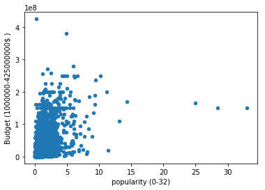

```python
#plot to analyse the correlation between revenue and popularity of the movies under different productions grouped

plot_4 = bud_prod_df.plot(x='popularity',y='budget',kind='scatter')
plot_4.set_xlabel("popularity (0-32)")
plot_4.set_ylabel("Budget (1000000-425000000$ )")
```

```python
#production company with highest budget and grouped by
bud_prod_df['budget'].nlargest(10)
```

```
production_companies
Boram Entertainment Inc.                                                                                                    425000000.0
Walt Disney Pictures|Jerry Bruckheimer Films|Moving Picture Company (MPC)                                                   380000000.0
Marvel Studios|Prime Focus|Revolution Sun Studios                                                                           280000000.0
DC Comics|Legendary Pictures|Warner Bros.|Bad Hat Harry Productions                                                         270000000.0
Columbia Pictures|Laura Ziskin Productions|Marvel Enterprises                                                               258000000.0
Walt Disney Pictures|Jerry Bruckheimer Films|Infinitum Nihil|Silver Bullet Productions (II)|Blind Wink Productions          255000000.0
Legendary Pictures|Warner Bros.|DC Entertainment|Syncopy                                                                    250000000.0
Twentieth Century Fox Film Corporation|Donners' Company|Marvel Entertainment|Bad Hat Harry Productions|TSG Entertainment    250000000.0
Walt Disney Pictures|Jerry Bruckheimer Films|Second Mate Productions                                                        250000000.0
Warner Bros.|Heyday Films                                                                                                   250000000.0
Name: budget, dtype: float64
```

```python
#describing the stats of budget vs popular productions
bud_prod_df.describe()
```

|  | popularity | budget |
| --- | --- | --- |
| count | 3008.000000 | 3.008000e+03 |
| mean | 1.210471 | 3.728074e+07 |
| std | 1.505667 | 4.156083e+07 |
| min | 0.010335 | 1.000000e+00 |
| 25% | 0.484249 | 1.000000e+07 |
| 50% | 0.828120 | 2.500000e+07 |
| 75% | 1.380126 | 5.000000e+07 |
| max | 32.985763 | 4.250000e+08 |

**Observations:**

There is a positive correlation between the budget and popularity of the movies grouped under different productions but the correlation is not highly significant.

For initial values the correlation is significant , but on later stages though the budget of the movie is high ,its still not popular.

### Research Question 8 (Revenue vs Popularity of Production Companies)

```python
#analysing histogram of revenue of popular productions
rev_prod_df = df1.groupby('production_companies')['popularity','revenue'].mean()
rev_prod_df
```

| production_companies | popularity | revenue |
| --- | --- | --- |
| 10th Hole Productions\|Benaroya Pictures\|Four of a Kind Productions | 0.385851 | 1.238200e+05 |
| 120dB Films\|Scion Films\|Voodoo Production Services\|Chydzik Media Group\|First Wedding Productions | 0.520430 | 1.378000e+03 |
| 1492 Pictures\|Dune Entertainment\|Fox 2000 Pictures\|Sunswept Entertainment\|Dune Entertainment III | 2.032753 | 1.745788e+08 |
| 1492 Pictures\|Warner Bros.\|Heyday Films | 8.021423 | 9.764756e+08 |
| 1492 Pictures\|Warner Bros.\|Heyday Films\|MIRACLE Productions GmbH & Co. KG | 6.012584 | 8.766885e+08 |
| 1492 Pictures\|Warner Bros.\|Heyday Films\|P of A Productions Limited | 5.827781 | 7.898046e+08 |
| 1818\|Lone Wolf McQuade Associates\|Topkick Productions | 0.290596 | 1.223263e+07 |
| 20th Century Fox | 0.692946 | 8.819377e+07 |
| 20th Century Fox\|1492 Pictures | 0.263042 | 5.409517e+06 |
| 20th Century Fox\|Chernin Entertainment\|Walden Media | 0.494391 | 1.197722e+08 |
| 20th Century Fox\|Davis Entertainment | 1.651962 | 2.243328e+07 |
| 20th Century Fox\|Double Feature Films\|Appian Way\|Stone Village Pictures\|New Regency Pictures | 1.321896 | 6.261665e+07 |
| 20th Century Fox\|Figment Films | 0.626782 | 1.440569e+08 |
| 20th Century Fox\|Gladden Entertainment | 0.200760 | 4.272120e+07 |
| 20th Century Fox\|Largo Entertainment\|JVC Entertainment Networks | 0.367997 | 5.713872e+07 |
| 20th Century Fox\|Regency Enterprises | 0.832959 | 4.444500e+07 |
| 20th Century Fox\|Regency Enterprises\|Guy Walks into a Bar Productions\|Deep River Productions | 0.498026 | 5.065008e+07 |
| 20th Century Fox\|Regency Enterprises\|New Regency Pictures\|Taurus Film\|Polar Entertainment Corporation | 0.231418 | 4.398989e+06 |
| 20th Century Fox\|Saban Entertainment | 0.223994 | 1.797974e+07 |
| 20th Century Fox\|Turner Pictures | 0.776380 | 1.367069e+07 |
| 20th Century Fox\|Village Roadshow Pictures\|NPV Entertainment\|Regency Enterprises\|Kopelson Entertainment | 0.651040 | 1.000201e+08 |
| 20th Century Fox\|Weed Road Pictures\|Dutch Oven\|New Regency Productions\|Summit Entertainment | 1.330824 | 4.782075e+08 |
| 20th Century Fox\|Zucker Brothers Productions | 0.760076 | 5.001251e+07 |
| 21 Laps Entertainment\|Andrew Lauren Productions (ALP)\|A24 | 1.116296 | 6.854611e+06 |
| 26 Films | 0.241541 | 5.508900e+04 |
| 2929 Productions | 0.455180 | 3.148182e+06 |
| 2929 Productions\|Dimension Films\|Nick Wechsler Productions\|Chockstone Pictures | 1.218657 | 2.763530e+07 |
| 2929 Productions\|Linson Entertainment\|Art Linson Productions\|Tribeca Productions | 0.368391 | 6.673422e+06 |
| 2929 Productions\|Magnolia Pictures\|Extension 765 | 0.272422 | 1.007962e+06 |
| 3 Arts Entertainment\|The Mark Gordon Company | 0.536350 | 3.566225e+06 |
| ... | ... | ... |
| WingNut Films\|TriStar Pictures\|Key Creatives\|Block / Hanson\|Canadian Film or Video Production Tax Credit (CPTC) | 3.744956 | 2.108196e+08 |
| WingNut Films\|Universal Pictures | 0.923851 | 2.935922e+07 |
| WingNut Films\|Universal Pictures\|Big Primate Pictures\|MFPV Film | 1.508329 | 5.500000e+08 |
| Wonderland Sound and Vision\|CBS Films\|Vast Entertainment | 1.758618 | 4.352863e+07 |
| Woods Entertainment\|Dimension Films | 1.286189 | 1.730467e+08 |
| Working Dog\|Village Roadshow Entertainment | 0.065672 | 8.617890e+05 |
| Working Title Films | 2.025604 | 6.616202e+07 |
| Working Title Films\|Circle Films | 0.693523 | 6.153939e+06 |
| Working Title Films\|Cross Creek Pictures\|Anton Capital Entertainment (ACE) | 2.281350 | 4.297299e+07 |
| Worldview Entertainment | 0.475977 | 6.427467e+04 |
| Worldview Entertainment\|Arcade Pictures | 0.412492 | 9.221000e+03 |
| Worldview Entertainment\|Dragonfly Entertainment\|Sobras International Pictures\|Top Hat Releasing\|BH Tilt | 0.890965 | 6.833445e+06 |
| Worldview Entertainment\|Muskat Filmed Properties\|Dreambridge Films\|Rough House Pictures | 0.340308 | 2.365467e+06 |
| Worldview Entertainment\|New Regency Pictures\|TSG Entertainment\|Le Grisbi Productions\|M Productions | 6.907148 | 1.032151e+08 |
| Yari Film Group | 0.151442 | 1.171860e+07 |
| Yari Film Group\|Furst Films | 0.084240 | 3.822670e+05 |
| Yash Raj Films | 0.320908 | 4.639643e+07 |
| Zenith Entertainment\|Initial Pictures\|U.K. Productions Entity | 0.506902 | 2.826523e+06 |
| Zentropa Entertainments\|Danmarks Radio (DR)\|Arte\|Memfis Film\|Isabella Films BV | 0.449064 | 6.749180e+05 |
| Zentropa Entertainments\|Det Danske Filminstitut\|Danmarks Radio (DR)\|Filmstiftung Nordrhein-Westfalen\|TrollhÃ¤ttan Film AB | 0.953705 | 7.918670e+05 |
| Zininsa Film Production\|Intellectual Properties Worldwide | 0.168979 | 4.040588e+06 |
| Zoetrope Studios | 2.319520 | 8.347151e+07 |
| Zoetrope Studios\|Golan-Globus Productions | 0.598029 | 3.221568e+06 |
| Zweites Deutsches Fernsehen (ZDF)\|Les Films Ariane\|RAI Radiotelevisione Italiana\|Cristaldifilm | 0.889306 | 7.720000e+07 |
| abramoff Production\|Scorpion Film Production\|Abramoff Production | 0.076438 | 4.192440e+06 |
| area japan | 0.127310 | 3.170000e+05 |
| chateau productions | 0.439210 | 1.100000e+01 |
| erbp | 0.476673 | 4.440980e+05 |
| iDeal Partners Film Fund | 0.315527 | 5.512500e+04 |
| icon | 0.276911 | 3.031801e+06 |

3008 rows × 2 columns

```
Text(0,0.5,'Revenue (2000000-2781506000$ )')
```

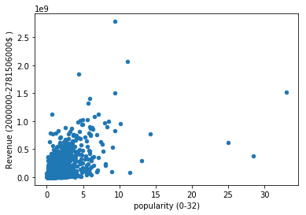

```python
#plot to analyse the correlation between revenue and popularity of the movies under different productions grouped

plot_5 = rev_prod_df.plot(x='popularity',y='revenue',kind='scatter')
plot_5.set_xlabel("popularity (0-32)")
plot_5.set_ylabel("Revenue (2000000-2781506000$ )")
```

```python
#analysing top 10 revenues of the production companies
rev_prod_df['revenue'].nlargest(10)
```

```
production_companies
Ingenious Film Partners|Twentieth Century Fox Film Corporation|Dune Entertainment|Lightstorm Entertainment    2.781506e+09
Lucasfilm|Truenorth Productions|Bad Robot                                                                     2.068178e+09
Paramount Pictures|Twentieth Century Fox Film Corporation|Lightstorm Entertainment                            1.845034e+09
Universal Studios|Amblin Entertainment|Legendary Pictures|Fuji Television Network|Dentsu                      1.513529e+09
Universal Pictures|Original Film|Media Rights Capital|Dentsu|One Race Films                                   1.506249e+09
Marvel Studios|Prime Focus|Revolution Sun Studios                                                             1.405036e+09
Warner Bros.|Heyday Films|Moving Picture Company (MPC)                                                        1.327818e+09
Paramount Pictures|Di Bonaventura Pictures|Hasbro|Indochina Productions                                       1.123747e+09
WingNut Films|New Line Cinema                                                                                 1.118889e+09
Legendary Pictures|Warner Bros.|DC Entertainment|Syncopy                                                      1.081041e+09
Name: revenue, dtype: float64
```

```python
#describing the movie revenues aggregate by production_companies
rev_prod_df.describe()
```

|  | popularity | revenue |
| --- | --- | --- |
| count | 3008.000000 | 3.008000e+03 |
| mean | 1.210471 | 1.017240e+08 |
| std | 1.505667 | 1.669925e+08 |
| min | 0.010335 | 2.000000e+00 |
| 25% | 0.484249 | 1.300701e+07 |
| 50% | 0.828120 | 4.406066e+07 |
| 75% | 1.380126 | 1.201052e+08 |
| max | 32.985763 | 2.781506e+09 |

**Observations**

From the plot its obvious that for movies that are grouped under different productions, have positive correlation of popularity with revenue but not very significant.